# EpiClass accurately predicts EpiATLAS assay and biospecimen metadata

- Show All Code
- Hide All Code
- View Source

Author

Joanny Raby

# Results section 2: Figures and their code

The formatting of the figures may differ slightly from those in the paper, but they display the same data points.

All code cells are folded by default. To view any cell, click **“Code”** to expand it, or use the code options near the main title above to unfold all at once.

Some code may be repeated, as the original Python notebook was designed for figures to be generated semi-independently.

## Setup Code - Imports and co.

Setup imports.

```python
from __future__ import annotations

import itertools
import re
import tarfile
from pathlib import Path
from typing import Dict, List, Sequence

import numpy as np
import pandas as pd
import plotly.express as px
import plotly.graph_objects as go
from IPython.display import display
from plotly.subplots import make_subplots
from scipy.stats import zscore

from epiclass.utils.notebooks.paper.paper_utilities import (
    ASSAY,
    ASSAY_MERGE_DICT,
    ASSAY_ORDER,
    BIOMATERIAL_TYPE,
    CELL_TYPE,
    LIFE_STAGE,
    SEX,
    IHECColorMap,
    MetadataHandler,
    SplitResultsHandler,
    create_mislabel_corrector,
    PathChecker
)

CORE7_ASSAYS = ASSAY_ORDER[0:7]
```

Setup paths.

```python
# Root path
base_dir = Path.home() / "Projects/epiclass/output/paper"
PathChecker.check_directory(base_dir)

# More precise
base_data_dir = base_dir / "data"
base_fig_dir = base_dir / "figures"
table_dir = base_dir / "tables"
metadata_dir = base_data_dir / "metadata"

official_metadata_dir = metadata_dir / "epiatlas" / "official"
PathChecker.check_directory(official_metadata_dir)

# alias
paper_dir = base_dir
```

Setup colors.

```python
IHECColorMap = IHECColorMap(base_fig_dir)
assay_colors = IHECColorMap.assay_color_map
cell_type_colors = IHECColorMap.cell_type_color_map
sex_colors = IHECColorMap.sex_color_map
```

Setup metadata and prediction files handlers.

```python
split_results_handler = SplitResultsHandler()

metadata_handler = MetadataHandler(paper_dir)
metadata_v2 = metadata_handler.load_metadata("v2")
metadata_v2_df = metadata_v2.to_df()
```

Setup figures general settings.

```python
main_title_settings = {
    "title":dict(
        automargin=True,
        x=0.5,
        xanchor="center",
        yanchor="top",
        y=0.98
        ),
    "margin":dict(t=50, l=10, r=10)
}
```

## Figure 2

### A,B - MLP performance on various classification tasks (100kb resolution)

- 2A: Accuracy
- 2B: F1-Score
- Supp 5A: AUC scores

Define function that graphs performance accross classification tasks.

```python
def NN_performance_across_classification_tasks(
    split_metrics: Dict[str, Dict[str, Dict[str, float]]],
    exclude_categories: List[str] | None = None,
    y_range: List[float] | None = None,
    sort_by_acc: bool = False,
    metric_names: Sequence[str] = ("Accuracy", "F1_macro"),
    title: str | None = None,
) -> List[str]:
    """Render box plots of metrics per classifier and split, each in its own subplot.

    This function generates a figure with subplots, each representing a different
    metric. Each subplot contains box plots for each classifier, ordered by accuracy.

    Args:
        split_metrics: A nested dictionary with structure {split: {classifier: {metric: score}}}.
        exclude_categories: Task categories to exclude from the plot.
        y_range: The y-axis range for the plots.
        sort_by_acc: Whether to sort the classifiers by accuracy.
        metric_names: The metrics to include in the plot.

    Returns:
        The list of classifier names in the order they appear in the plot.
    """
    # Exclude some categories
    classifier_names = list(split_metrics["split0"].keys())
    if exclude_categories is not None:
        for category in exclude_categories:
            classifier_names = [c for c in classifier_names if category not in c]

    available_metrics = list(split_metrics["split0"][classifier_names[0]].keys())
    try:
        available_metrics.remove("count")
    except ValueError:
        pass
    if any(metric not in available_metrics for metric in metric_names):
        raise ValueError(f"Invalid metric. Metrics need to be in {available_metrics}")

    # Get classifier counts
    classifiers_N = split_results_handler.extract_count_from_metrics(split_metrics)

    # Sort classifiers by accuracy
    if sort_by_acc:
        mean_acc = {}
        for classifier in classifier_names:
            mean_acc[classifier] = np.mean(
                [split_metrics[split][classifier]["Accuracy"] for split in split_metrics]
            )
        classifier_names = sorted(
            classifier_names, key=lambda x: mean_acc[x], reverse=True
        )

    # Create subplots, one column for each metric
    fig = make_subplots(
        rows=1,
        cols=len(metric_names),
        subplot_titles=metric_names,
        horizontal_spacing=0.03,
    )

    color_group = px.colors.qualitative.Plotly
    colors = {
        classifier: color_group[i % len(color_group)]
        for i, classifier in enumerate(classifier_names)
    }

    point_pos = 0
    for i, metric in enumerate(metric_names):
        for classifier_name in classifier_names:
            values = [
                split_metrics[split][classifier_name][metric] for split in split_metrics
            ]

            fig.add_trace(
                go.Box(
                    x=[classifier_name] * len(values),
                    y=values,
                    name=f"{classifier_name} (N={classifiers_N[classifier_name]})",
                    fillcolor=colors[classifier_name],
                    line=dict(color="black", width=1.5),
                    marker=dict(size=3, color="white", line_width=1),
                    boxmean=True,
                    boxpoints="all",
                    pointpos=point_pos,
                    showlegend=i == 0,  # Only show legend in the first subplot
                    hovertemplate="%{text}",
                    text=[
                        f"{split}: {value:.4f}"
                        for split, value in zip(split_metrics, values)
                    ],
                    legendgroup=classifier_name,
                    width=0.5,
                ),
                row=1,
                col=i + 1,
            )

    # Title
    title_text = (
        "Neural network classification - Metric distribution for 10-fold cross-validation"
    )
    if title:
        title_text = title
    fig.update_layout(title_text=title_text, **main_title_settings)

    # Layout
    fig.update_layout(
        yaxis_title="Value",
        boxmode="group",
        height=1200 * 0.8,
    )

    # Acc, F1
    fig.update_layout(yaxis=dict(range=[0.88, 1.001]))
    fig.update_layout(yaxis2=dict(range=[0.80, 1.001]))

    # AUC
    range_auc = [0.986, 1.0001]
    fig.update_layout(yaxis3=dict(range=range_auc))
    fig.update_layout(yaxis4=dict(range=range_auc))

    if y_range is not None:
        fig.update_yaxes(range=y_range)

    fig.show()

    return classifier_names
```

Compute metrics.

```python
exclude_categories = ["track_type", "group", "disease", "PE", "martin"]
# exclude_categories = ["track_type", "group", "disease"]
exclude_names = ["chip-seq", "7c", "16ct", "no-mixed"]

hdf5_type = "hg38_100kb_all_none"
results_dir = base_data_dir / "training_results" / "dfreeze_v2" / hdf5_type
PathChecker.check_directory(results_dir)

mislabel_correction = True
if mislabel_correction:
    mislabel_corrector = create_mislabel_corrector(paper_dir)
else:
    mislabel_corrector = None

split_results_metrics, all_split_results = split_results_handler.general_split_metrics(
    results_dir,
    merge_assays=True,
    exclude_categories=exclude_categories,
    exclude_names=exclude_names,
    return_type="both",
    oversampled_only=True,
    mislabel_corrections=mislabel_corrector,
    verbose=False,
)
```

Graph metrics.

```python
metrics_full = ["Accuracy", "F1_macro", "AUC_micro", "AUC_macro"]
fig_name = f"{hdf5_type}_perf_across_categories_full"
sorted_task_names = NN_performance_across_classification_tasks(
    split_results_metrics,  # type: ignore
    sort_by_acc=True,
    metric_names=metrics_full,
)
```

[interactive chart not shown]

Fig. 2A,B: Distribution of accuracy and F1-score evaluated per training fold (dots) for each metadata classifier. Performance metrics are reported without applying a prediction score threshold. Dashed lines represent means, solid lines the medians, boxes the quartiles, and whiskers the farthest points within 1.5× the interquartile range.

### C - Class imbalance (Shannon Entropy)

Define function `compute_class_imbalance`.

```python
def compute_class_imbalance(
    all_split_results: Dict[str, Dict[str, pd.DataFrame]],
) -> pd.DataFrame:
    """Compute class imbalance for each task and split.

    Args:
        all_split_results: A dictionary with structure {task_name: {split_name: split_results_df}}.

    Returns:
        pd.DataFrame: A DataFrame with the following columns:
            - avg(balance_ratio): The average balance ratio for each task.
            - n: The number of classes for each task (used for the average).
    """
    # combine md5 lists
    task_md5s = {
        classifier_task: [split_df.index for split_df in split_results.values()]
        for classifier_task, split_results in all_split_results.items()
    }
    task_md5s = {
        classifier_task: [list(split_md5s) for split_md5s in md5s]
        for classifier_task, md5s in task_md5s.items()
    }
    task_md5s = {
        classifier_task: list(itertools.chain(*md5s))
        for classifier_task, md5s in task_md5s.items()
    }

    # get metadata
    metadata_df = metadata_handler.load_metadata_df("v2-encode")

    label_counts = {}
    for classifier_task, md5s in task_md5s.items():
        try:
            label_counts[classifier_task] = metadata_df.loc[md5s][
                classifier_task
            ].value_counts()
        except KeyError as e:
            category_name = classifier_task.rsplit("_", maxsplit=1)[0]
            try:
                label_counts[classifier_task] = metadata_df.loc[md5s][
                    category_name
                ].value_counts()
            except KeyError as e:
                raise e

    # Compute Shannon Entropy
    class_balance = {}
    for classifier_task, counts in label_counts.items():
        total_count = counts.sum()
        k = len(counts)
        p_x = counts / total_count  # class proportions
        p_x = p_x.values
        shannon_entropy = -np.sum(p_x * np.log2(p_x))
        balance = shannon_entropy / np.log2(k)
        class_balance[classifier_task] = (balance, k)

    df_class_balance = pd.DataFrame.from_dict(
        class_balance, orient="index", columns=["Normalized Shannon Entropy", "k"]
    ).sort_index()

    return df_class_balance
```

Compute class imbalance (Shannon entropy).

```python
subset = {
    k: v
    for k, v in all_split_results.items()  # type: ignore
    if not any(label in k for label in ["martin", "PE"])
}
df_class_balance = compute_class_imbalance(subset)  # type: ignore
```

Define graphing function `plot_shannon_entropy`.

```python
def plot_shannon_entropy(class_balance_df: pd.DataFrame, ordered_task_names: List[str]|None) -> None:
    """Graph Shannon entropy values, in the order given by ordered_task_names."""
    df = class_balance_df.copy()

    if ordered_task_names:
        df = df.loc[[t for t in ordered_task_names if t in df.index]]

    fig = px.scatter(
        df,
        x=df.index,
        y="Normalized Shannon Entropy",
        title="Class imbalance across tasks (higher is more balanced)",
    )
    fig.update_layout(
        yaxis=dict(range=[0, 1]),
        xaxis_title=None,
        margin=dict(r=60),
    )
    fig.show()
```

Graph.

```python
plot_shannon_entropy(
    class_balance_df=df_class_balance,
    ordered_task_names=sorted_task_names,
    )
```

[interactive chart not shown]

Fig. 2C: Shannon entropy scores for each metadata category.

### D - Donor Sex classification

`IHEC_sample_metadata_harmonization.v1.1.extended.csv` contains 314 EpiRRs with unknown sex. We applied a fully trained sex classifier on those.

To properly create sex classification related graphs (D,E) we need

```
- Classifier predictions on samples with unknown sex label
- Metadata pre/post correction
- Average ChrY signal for each file
```

Load v1.1 and v1.2 official metadata.

```python
metadata_v1_1_path = (
    official_metadata_dir / "IHEC_sample_metadata_harmonization.v1.1.extended.csv"
)
metadata_v1_1 = pd.read_csv(metadata_v1_1_path, index_col=0)

metadata_v1_2_path = (
    official_metadata_dir / "IHEC_sample_metadata_harmonization.v1.2.extended.csv"
)
metadata_v1_2 = pd.read_csv(metadata_v1_2_path, index_col=0)
```

Sanity check: make sure that the number of unknown labels is the same in our metadata VS official v1.1

```python
full_metadata_df = metadata_v2_df
full_metadata_df["md5sum"] = full_metadata_df.index
assert (
    metadata_v2_df[metadata_v2_df[SEX].isin(["unknown"])]["EpiRR"].nunique()
    == metadata_v1_1[metadata_v1_1[SEX] == "unknown"].index.nunique()
    == 314
)
```

Load predictions for unknown sex samples.

```python
sex_results_dir = (
    base_data_dir
    / "training_results"
    / "dfreeze_v2"
    / "hg38_100kb_all_none"
    / f"{SEX}_1l_3000n"
)
sex_full_model_dir = sex_results_dir / "complete_no_valid_oversample"
PathChecker.check_directory(sex_full_model_dir)

pred_unknown_file_path = (
    sex_full_model_dir
    / "predictions"
    / "complete_no_valid_oversample_test_prediction_100kb_all_none_dfreeze_v2.1_sex_mixed_unknown.csv"
)
pred_unknown_df = pd.read_csv(pred_unknown_file_path, index_col=0, header=0)
```

Join metadata to predictions.

```python
pred_unknown_df = pred_unknown_df[pred_unknown_df["True class"] == "unknown"]
pred_unknown_df = split_results_handler.add_max_pred(pred_unknown_df)  # type: ignore
pred_unknown_df = metadata_handler.join_metadata(pred_unknown_df, metadata_v2)
pred_unknown_df["md5sum"] = pred_unknown_df.index
```

Load 10-fold cross validation results.

```python
sex_10fold_dir = sex_results_dir / "10fold-oversampling"
PathChecker.check_directory(sex_10fold_dir)

split_results: Dict[str, pd.DataFrame] = split_results_handler.read_split_results(
    sex_10fold_dir
)
concat_results_10fold: pd.DataFrame = split_results_handler.concatenate_split_results(split_results, depth=1)  # type: ignore
concat_results_10fold = split_results_handler.add_max_pred(concat_results_10fold)
concat_results_10fold = metadata_handler.join_metadata(concat_results_10fold, metadata_v2)
```

#### Inner portion

Fig. 2D: Proportion of donor sex metadata originally annotated (inner circle, metadata v1.1) and predicted with high-confidence (outer circle, metadata v2.0) for female (red) and male (blue) (mixed sex not shown).

Compute values for the inner portion of the pie chart.

```python
# Proportion of unknown, excluding mixed. same as v1.1 ihec metadata
no_mixed = full_metadata_df[full_metadata_df[SEX] != "mixed"]

with pd.option_context("display.float_format", "{:.2%}".format):
    print("file-wise:")
    print(no_mixed[SEX].value_counts(dropna=False) / no_mixed.shape[0])

    print("\nEpiRR-wise:")
    epirr_no_mixed = no_mixed.drop_duplicates(subset=["EpiRR"])
    print(epirr_no_mixed[SEX].value_counts(dropna=False) / epirr_no_mixed.shape[0])
```

```
file-wise:
harmonized_donor_sex
female    44.88%
male      42.41%
unknown   12.71%
Name: count, dtype: float64

EpiRR-wise:
harmonized_donor_sex
male      45.14%
female    40.60%
unknown   14.26%
Name: count, dtype: float64
```

#### Outer portion

Outer ring represents SEX metadata labnels v1.2 (without `mixed` labels), which had those modifications:

- Some unknown SEX files were labelled, using (assay,track type) z-score in conjunction with fully trained model predictions.
- Correction of some mislabels, using 10fold cross-validation results

```python
meta_v1_2_no_mixed = metadata_v1_2[metadata_v1_2[SEX] != "mixed"]
with pd.option_context("display.float_format", "{:.2%}".format):
    print("EpiRR-wise:")
    print(meta_v1_2_no_mixed.value_counts(SEX) / meta_v1_2_no_mixed.shape[0])
```

```
EpiRR-wise:
harmonized_donor_sex
male      51.42%
female    46.54%
unknown    2.04%
Name: count, dtype: float64
```

#### Average chrY values z-score distributions

Work done in another script:

1. For each bigwig file, the chrY average value is computed with the pyBigWig module, in `chrY_bigwig_mean.py` ([permalink](https://github.com/labjacquespe/EpiClass/blob/e87306bccecd3e35d9ffdbb5ddb29fcaa0800a35/src/python/epiclass/utils/chrY_bigwig_mean.py)).
2. For each assay, the z-score distribution (of the mean chrY value) of the file group is computed.
   - Outputs `chrXY_all.csv`
   - Outputs `chrY_zscores.csv`

Fig. 2E is made by averaging for each EpiRR the z-score value in each assay distribution.

This data is needed for the full sex mislabel context table.  
Define function `compute_chrY_zscores`.

```python
def compute_chrY_zscores(
    chrY_dir: Path, version: str, save: bool = False
) -> pd.DataFrame:
    """Compute z-scores for chrY signal data.

    Computes two distributions of z-scores:
    1) Per assay group, excluding raw, pval, and Unique_raw tracks.
    2) Per assay+track group.

    In both cases, rna-seq/mrna-seq and wgbs-standard/wgbs-pbat are put as one assay.

    Args:
        chrY_dir: The directory containing the chrY signal data.
        version: The metadata version to use.
        save: Whether to save the results.

    Returns:
        pd.DataFrame: The chrY signal data with z-scores appended.
    """
    output_dir: Path = chrY_dir
    if save:
        output_dir = chrY_dir / f"dfreeze_{version}_stats"
        output_dir.mkdir(parents=False, exist_ok=True)

    # Get chrY signal data
    chrY_df = pd.read_csv(chrY_dir / "chrXY_all.csv", header=0)

    # Filter out md5s not in metadata version
    metadata = MetadataHandler(paper_dir).load_metadata(version)
    md5s = set(metadata.signal_ids)
    chrY_df = chrY_df[chrY_df["filename"].isin(md5s)]

    # Make sure all values are non-zero
    if not (chrY_df["chrY"] != 0).all():
        raise ValueError("Some chrY values are zero.")

    # Merge metadata
    metadata_df = pd.DataFrame.from_records(list(metadata.datasets))
    metadata_df.replace({ASSAY: ASSAY_MERGE_DICT}, inplace=True)
    chrY_df = chrY_df.merge(
        metadata_df, left_on="filename", right_on="md5sum"
    )

    # Compute stats for distributions
    metric_name_1 = "chrY_zscore_vs_assay_w_track_exclusion"
    metric_name_2 = "chrY_zscore_vs_assay_track"
    files1 = chrY_df[
        ~chrY_df["track_type"].isin(["raw", "pval", "Unique_raw"])
    ]
    files2 = chrY_df
    dist1 = files1.groupby(ASSAY).agg({"chrY": ["mean", "std", "count"]})
    dist2 = files2.groupby([ASSAY, "track_type"]).agg({"chrY": ["mean", "std", "count"]})
    if save:
        dist1.to_csv(output_dir / "chrY_stats_assay_w_track_exclusion.csv")
        dist2.to_csv(output_dir / "chrY_stats_assay_and_track.csv")

    # Compute full z-score distributions
    for groups in files1.groupby(ASSAY):
        _, group_df = groups
        group_df["zscore"] = zscore(group_df["chrY"])
        chrY_df.loc[group_df.index, metric_name_1] = group_df["zscore"]
        chrY_df.loc[group_df.index, f"N_{metric_name_1}"] = groups[1].shape[0]
    for groups in files2.groupby([ASSAY, "track_type"]):
        _, group_df = groups
        group_df["zscore"] = zscore(group_df["chrY"])
        chrY_df.loc[group_df.index, metric_name_2] = group_df["zscore"]
        chrY_df.loc[group_df.index, f"N_{metric_name_2}"] = groups[1].shape[0]

    # Fill in missing values
    for N_name in [f"N_{metric_name_1}", f"N_{metric_name_2}"]:
        chrY_df[N_name] = chrY_df[N_name].fillna(0).astype(int)
    chrY_df.fillna(pd.NA, inplace=True)

    if save:
        output_cols = [
            "filename",
            ASSAY,
            "track_type",
            "chrY",
            metric_name_1,
            f"N_{metric_name_1}",
            metric_name_2,
            f"N_{metric_name_2}",
        ]
        chrY_df[output_cols].to_csv(
            output_dir / "chrY_zscores.csv", index=False, na_rep="NA"  # type: ignore
        )
    return chrY_df
```

Compute chrY zscores.

```python
chrY_dir = base_data_dir / "chrY"
PathChecker.check_directory(chrY_dir)

chrY_df = compute_chrY_zscores(chrY_dir, "v2", save=False)
```

#### Unknown predictions analysis file

The following folded code generates a similar table to what was used to determine which unknown sex sample to label. It was not used to produce any graph.

```python
def create_sex_pred_pivot_table(pred_unknown: pd.DataFrame, chrY_df: pd.DataFrame) -> pd.DataFrame:
    """Generate a pivot table containing group metrics per predicted label, for each EpiRR."""
    index_cols = [
        "EpiRR",
        "project",
        "harmonized_donor_type",
        CELL_TYPE,
        SEX,
        "Predicted class",
    ]
    pred_plus_chrY_df = pd.merge(
        pred_unknown,
        chrY_df,
        on="md5sum",
        suffixes=("", "_DROP")
    )
    pred_plus_chrY_df.drop(
        columns=[c for c in pred_plus_chrY_df.columns if c.endswith("_DROP")],
        inplace=True,
    )

    val_cols = ["Max pred", "chrY_zscore_vs_assay_track"]
    pivot_table = pred_plus_chrY_df.pivot_table(
        index=index_cols,
        values=val_cols,
        aggfunc=["mean", "median", "std", "count"],
    )

    return pivot_table


create_sex_pred_pivot_table(
    pred_unknown=pred_unknown_df,
    chrY_df=chrY_df,
)
```

| EpiRR | project | harmonized_donor_type | harmonized_sample_ontology_intermediate | harmonized_donor_sex | Predicted class | mean Max pred | mean chrY_zscore_vs_assay_track | median Max pred | median chrY_zscore_vs_assay_track | std Max pred | std chrY_zscore_vs_assay_track | count Max pred | count chrY_zscore_vs_assay_track |
| --- | --- | --- | --- | --- | --- | --- | --- | --- | --- | --- | --- | --- | --- |
| IHECRE00000036.3 | BLUEPRINT | Single donor | hematopoietic cell | unknown | male | 0.781766 | -0.081182 | 0.781766 | -0.081182 | NaN | NaN | 1 | 1 |
| IHECRE00000042.3 | BLUEPRINT | Single donor | hematopoietic cell | unknown | male | 0.556080 | -0.880438 | 0.556080 | -0.880438 | NaN | NaN | 1 | 1 |
| IHECRE00000047.3 | BLUEPRINT | Single donor | hematopoietic cell | unknown | female | 0.769686 | -0.876301 | 0.769686 | -0.876301 | NaN | NaN | 1 | 1 |
| IHECRE00000067.3 | BLUEPRINT | Single donor | hematopoietic cell | unknown | male | 0.964230 | 0.620305 | 0.964230 | 0.620305 | NaN | NaN | 1 | 1 |
| IHECRE00000069.3 | BLUEPRINT | Single donor | hematopoietic cell | unknown | male | 0.978939 | 0.398611 | 0.978939 | 0.398611 | NaN | NaN | 1 | 1 |
| ... | ... | ... | ... | ... | ... | ... | ... | ... | ... | ... | ... | ... | ... |
| IHECRE00004904.1 | NIH Roadmap Epigenomics | Single donor | neural progenitor cell | unknown | female | 0.679335 | -0.536291 | 0.679335 | -0.536291 | 0.013960 | 0.113480 | 2 | 2 |
| IHECRE00004908.1 | NIH Roadmap Epigenomics | Single donor | placenta | unknown | female | 0.590977 | -0.458150 | 0.590977 | -0.458150 | NaN | NaN | 1 | 1 |
|  |  |  |  |  | mixed | 0.893086 | -0.682532 | 0.893086 | -0.682532 | NaN | NaN | 1 | 1 |
| IHECRE00004910.1 | NIH Roadmap Epigenomics | Single donor | neural progenitor cell | unknown | female | 0.753894 | -0.288177 | 0.753894 | -0.288177 | NaN | NaN | 1 | 1 |
|  |  |  |  |  | male | 0.956916 | 0.402645 | 0.983646 | -0.383976 | 0.065293 | 1.434576 | 5 | 5 |

409 rows × 8 columns

#### 10fold cross-validation predictions analysis file

This section generates a similar table to what was used to determine which EpiRR sex labels might be mistaken. It aggregates results from the 10 cross-validation classifiers.

```python
cross_val_analysis = concat_results_10fold.merge(chrY_df, left_index=True, right_on="md5sum", suffixes=("", "_DROP"))  # type: ignore
cross_val_analysis.drop(
    columns=[c for c in cross_val_analysis.columns if c.endswith("_DROP")], inplace=True
)
```

```python
index_cols = [
    "EpiRR",
    "project",
    "harmonized_donor_type",
    CELL_TYPE,
    SEX,
    "Predicted class",
]
val_cols = ["Max pred", "chrY_zscore_vs_assay_track"]

# not directly used in full mislabel analysis
to_drop = [
    "N_chrY_zscore_vs_assay_w_track_exclusion",
    "chrY_zscore_vs_assay_w_track_exclusion",
]
cross_val_analysis_track = cross_val_analysis.drop(to_drop, axis=1)

pivot_table = cross_val_analysis_track.pivot_table(
    index=index_cols,
    values=val_cols,
    aggfunc=["mean", "median", "std", "count"],
)

display(pivot_table.head())
```

| EpiRR | project | harmonized_donor_type | harmonized_sample_ontology_intermediate | harmonized_donor_sex | Predicted class | mean Max pred | mean chrY_zscore_vs_assay_track | median Max pred | median chrY_zscore_vs_assay_track | std Max pred | std chrY_zscore_vs_assay_track | count Max pred | count chrY_zscore_vs_assay_track |
| --- | --- | --- | --- | --- | --- | --- | --- | --- | --- | --- | --- | --- | --- |
| IHECRE00000001.4 | CEEHRC | Single donor | epithelial cell derived cell line | female | female | 0.964847 | -0.649520 | 0.988930 | -0.677161 | 0.063663 | 0.405152 | 20 | 20 |
|  |  |  |  |  | mixed | 0.610971 | -0.378015 | 0.570102 | -0.568708 | 0.137748 | 0.653722 | 3 | 3 |
| IHECRE00000002.3 | BLUEPRINT | Single donor | myeloid cell | female | female | 0.963702 | -0.127269 | 0.996254 | -0.554242 | 0.096154 | 1.082720 | 20 | 20 |
| IHECRE00000004.3 | BLUEPRINT | Single donor | neutrophil | female | female | 0.833395 | -0.040080 | 0.900267 | -0.542614 | 0.177544 | 1.395165 | 18 | 18 |
|  |  |  |  |  | male | 0.651440 | 0.404992 | 0.651231 | -0.627901 | 0.115929 | 2.277509 | 5 | 5 |

### E - Average EpiRR z-score for 10fold

Define function `zscore_merged_assays` that computes the chrY average signal metric.

```python
def zscore_merged_assays(
    zscore_df: pd.DataFrame,
    sex_mislabels: Dict[str, str],
    min_pred: float | None = None,
    no_rna: bool = False,
) -> None:
    """Male vs Female z-score distribution for merged assays, excluding wgbs.

    Does not include pval and raw tracks.

    Highlights mislabels in the plot.

    Args:
        zscore_df (pd.DataFrame): The dataframe with z-score data.
        sex_mislabels (Dict[str, str]): {EpiRR_no-v: corrected_sex_label}
        min_pred (float|None): Minimum prediction value to include in the plot. Used on average EpiRR 'Max pred' values.
        no_rna (bool): Whether to exclude rna_seq from the plot.
    """
    zscore_df = zscore_df.copy(deep=True)

    # Remove pval/raw tracks + rna unstranded
    zscore_df = zscore_df[~zscore_df["track_type"].isin(["pval", "raw", "Unique_raw"])]

    # Merge rna protocols
    zscore_df.replace({ASSAY: ASSAY_MERGE_DICT}, inplace=True)

    # wgbs reverses male/female chrY tendency, so removed here
    zscore_df = zscore_df[~zscore_df[ASSAY].str.contains("wgb")]

    if no_rna:
        zscore_df = zscore_df[~zscore_df[ASSAY].str.contains("rna")]

    N_assays = len(zscore_df[ASSAY].unique())
    print(
        f"Average chrY z-score values computed from:\n{zscore_df[ASSAY].value_counts(dropna=False)}"
    )

    # Average chrY z-score values
    metric_label = "chrY_zscore_vs_assay_w_track_exclusion"
    zscore_df = zscore_df[zscore_df[metric_label] != "NA"]
    mean_chrY_values_df = zscore_df.groupby(["EpiRR", SEX]).agg(
        {metric_label: "mean", "Max pred": "mean"}
    )
    mean_chrY_values_df.reset_index(inplace=True)
    if not mean_chrY_values_df["EpiRR"].is_unique:
        raise ValueError("EpiRR is not unique.")

    # Filter out low prediction values
    if min_pred is not None:
        mean_chrY_values_df = mean_chrY_values_df[
            mean_chrY_values_df["Max pred"] > min_pred
        ]

    mean_chrY_values_df.reset_index(drop=True, inplace=True)
    mean_chrY_values_df["EpiRR_no_v"] = mean_chrY_values_df["EpiRR"].str.extract(
        pat=r"(\w+\d+).\d+"
    )[0]

    chrY_values = mean_chrY_values_df[metric_label]
    female_idx = np.argwhere((mean_chrY_values_df[SEX] == "female").values).flatten()  # type: ignore
    male_idx = np.argwhere((mean_chrY_values_df[SEX] == "male").values).flatten()  # type: ignore

    # Mislabels
    predicted_as_female = set(
        epirr_no_v for epirr_no_v, label in sex_mislabels.items() if label == "female"
    )
    predicted_as_male = set(
        epirr_no_v for epirr_no_v, label in sex_mislabels.items() if label == "male"
    )
    predicted_as_female_idx = np.argwhere(mean_chrY_values_df["EpiRR_no_v"].isin(predicted_as_female).values).flatten()  # type: ignore
    predicted_as_male_idx = np.argwhere(mean_chrY_values_df["EpiRR_no_v"].isin(predicted_as_male).values).flatten()  # type: ignore

    print(
        f"Adding mislabels to graph: {len(predicted_as_female_idx)} male->female, {len(predicted_as_male_idx)} female->male"
    )

    # Hovertext
    hovertext = [
        f"{epirr}: <z-score>={z_score:.3f}"
        for epirr, z_score in zip(
            mean_chrY_values_df["EpiRR"],
            mean_chrY_values_df[metric_label],
        )
    ]
    hovertext = np.array(hovertext)

    # sanity check
    if mean_chrY_values_df["EpiRR"].nunique() != mean_chrY_values_df.shape[0]:
        raise ValueError("EpiRR is not unique.")

    # Create figure
    fig = go.Figure()
    fig.add_trace(
        go.Box(
            name="Female",
            x=[0] * len(female_idx),
            y=chrY_values[female_idx],  # type: ignore
            boxmean=True,
            boxpoints="all",
            pointpos=-2,
            hovertemplate="%{text}",
            text=hovertext[female_idx],
            marker=dict(size=2),
            line=dict(width=1, color="black"),
            fillcolor=sex_colors["female"],
            showlegend=True,
        ),
    )

    fig.add_trace(
        go.Box(
            name="Male",
            x=[1] * len(female_idx),
            y=chrY_values[male_idx],  # type: ignore
            boxmean=True,
            boxpoints="all",
            pointpos=-2,
            hovertemplate="%{text}",
            text=hovertext[male_idx],
            marker=dict(size=2),
            line=dict(width=1, color="black"),
            fillcolor=sex_colors["male"],
            showlegend=True,
        ),
    )

    fig.add_trace(
        go.Scatter(
            name="Male",
            x=[-0.5] * len(predicted_as_male_idx),
            y=chrY_values[predicted_as_male_idx],  # type: ignore
            mode="markers",
            marker=dict(
                size=10, color=sex_colors["male"], line=dict(width=1, color="black")
            ),
            hovertemplate="%{text}",
            text=hovertext[predicted_as_male_idx],
            showlegend=False,
        ),
    )

    fig.add_trace(
        go.Scatter(
            name="Female",
            x=[0.5] * len(predicted_as_female_idx),
            y=chrY_values[predicted_as_female_idx],  # type: ignore
            mode="markers",
            marker=dict(
                size=10, color=sex_colors["female"], line=dict(width=1, color="black")
            ),
            hovertemplate="%{text}",
            text=hovertext[predicted_as_female_idx],
            showlegend=False,
        ),
    )

    fig.update_xaxes(showticklabels=False)

    fig.update_yaxes(range=[-1.5, 3])
    title = f"z-score(mean chrY signal per file) distribution - z-scores averaged over {N_assays} assays"
    if min_pred is not None:
        title += f"<br>avg_maxPred>{min_pred}"

    fig.update_layout(
        title=dict(text=title, x=0.5),
        xaxis_title=SEX,
        yaxis_title="Average z-score",
        height=750,
    )

    fig.show()
```

Graph zscores.

```python
zscore_merged_assays(
    zscore_df=cross_val_analysis,
    sex_mislabels=create_mislabel_corrector(paper_dir)[1][SEX],
    no_rna=True,
)
```

```
Average chrY z-score values computed from:
assay_epiclass
h3k27ac     1447
h3k4me1      850
h3k4me3      678
input        657
h3k36me3     595
h3k27me3     575
h3k9me3      537
Name: count, dtype: int64
Adding mislabels to graph: 8 male->female, 8 female->male
```

[interactive chart not shown]

Fig 2E: Distribution of the average z-score signal of epigenomes (dots) over chrY, computed on the ChIP-Seq datasets (up to 7 assays per epigenome) using the fold change track type files for female (red) and male (blue). Originally mislabeled epigenomes are shown as big dots. Boxplot elements are as in Fig. 2A.

### F - Donor life stage and GP-Age

Load official IHEC sample metadata.

```python
meta_v1_2_df = pd.read_csv(
    official_metadata_dir / "IHEC_sample_metadata_harmonization.v1.2.extended.csv"
)
meta_v1_1_df = pd.read_csv(
    official_metadata_dir / "IHEC_sample_metadata_harmonization.v1.1.extended.csv"
)
```

Sanity check, both metadata versions have the same ‘cell line’ samples.

```python
cell_lines_v11 = meta_v1_1_df[meta_v1_1_df[BIOMATERIAL_TYPE] == "cell line"][
    "epirr_id_without_version"
].unique()
cell_lines_v12 = meta_v1_2_df[meta_v1_2_df[BIOMATERIAL_TYPE] == "cell line"][
    "epirr_id_without_version"
].unique()
assert set(cell_lines_v11) == set(cell_lines_v12)
```

Load GP-age results.

```python
gp_age_dir = base_data_dir / "GP_age"
PathChecker.check_directory(gp_age_dir)

df_gp_age = pd.read_csv(gp_age_dir / "life_stage_prediction.GPage.20250513.tsv", sep="\t")
df_gp_age["graph_age"] = df_gp_age["model30"]

epiclass_pred_col = "epiclass_predicted_lifestage"

display(df_gp_age.head())
```

|  | epirr_noV | version | model30 | model71 | model30_imputed_data | model71_imputed_data | nbCpG_model30 | nbCpG_model71 | harmonized_donor_life_stage | harmonized_donor_age | harmonized_donor_age_unit | epiclass_predicted_lifestage | tissue | tissue_subtype | graph_age |
| --- | --- | --- | --- | --- | --- | --- | --- | --- | --- | --- | --- | --- | --- | --- | --- |
| 0 | IHECRE00000001 | 4 | 39.356 | 28.973 | 71.782 | 62.627 | 30 | 71 | unknown | unknown | unknown | adult_pred | REPR | breast | 39.356 |
| 1 | IHECRE00000004 | 3 | 49.972 | 46.109 | 53.737 | 49.893 | 30 | 70 | adult | 60-65 | year | adult | IMMU | blood-venous | 49.972 |
| 2 | IHECRE00000008 | 3 | 55.681 | 51.238 | 40.128 | 36.052 | 28 | 67 | adult | 50-55 | year | adult | IMMU | blood-venous | 55.681 |
| 3 | IHECRE00000013 | 3 | 61.915 | 64.748 | 35.262 | 32.777 | 29 | 67 | child | 0-5 | year | adult_pred | IMMU | blood-venous | 61.915 |
| 4 | IHECRE00000014 | 2 | 48.480 | 49.848 | 71.979 | 64.951 | 29 | 67 | adult | 70-75 | year | adult | IMMU | bone-marrow | 48.480 |

The `epiclass_predicted_lifestage` column is manually curated, from analyzing all predictions for all samples. When an expected label is known, and epiclass predictions are inconclusive (low average max pred and/or no majority consensus), the expected label is kept.

Columns `tissue` and `tissue_subtype` are formatting of `harmonized_sample_organ_system_order_AnetaMikulasova` and `harmonized_sample_organ_order_AnetaMikulasova`.  
Following code remaps 5 life stage classes to 3 (perinatal, pediatric, adult).

```python
df_gp_age.loc[:, "graph_age_categories"] = df_gp_age[epiclass_pred_col].str.removesuffix(
    "_pred"
)

gp_age_categories = {
    "adult": "adult",
    "child": "pediatric",
    "embryonic": "perinatal",
    "fetal": "perinatal",
    "newborn": "perinatal",
    "unknown": "unknown",
}
df_gp_age.loc[:, "graph_age_categories"] = df_gp_age["graph_age_categories"].map(
    gp_age_categories
)
display(df_gp_age["graph_age_categories"].value_counts(dropna=False))
```

```
graph_age_categories
adult        479
pediatric     54
perinatal     53
unknown       48
Name: count, dtype: int64
```

Here we merge GP-age data with additional EpiAtlas metadata.

```python
epirr_col = "epirr_id_without_version"

merged_dp_age = pd.merge(
    df_gp_age,
    meta_v1_2_df[[epirr_col, CELL_TYPE, BIOMATERIAL_TYPE]],
    left_on="epirr_noV",
    right_on=epirr_col,
    how="left",
)
merged_dp_age.drop_duplicates(subset=[epirr_col], inplace=True)
merged_dp_age.drop(columns=["epirr_noV"], inplace=True)
```

Excluding ‘cell line’ samples from considered data.

```python
# Removing cell lines: life stage makes less sense
# type: ignore
N_before = merged_dp_age.shape[0]
merged_dp_age: pd.DataFrame = merged_dp_age[
    merged_dp_age[BIOMATERIAL_TYPE] != "cell line"
]
print(f"Removed {N_before - merged_dp_age.shape[0]} cell lines.")
```

```
Removed 29 cell lines.
```

Creating the graph categories.

We need to categorize separately whole blood since from other tissues since GP-Age training is only made of whole blood. We keep ‘immune system’ tissues, specifically venous and umbilical blood since they match the most closely to the training data. unsure about blood marrow.

```python
layer1_vals = ["IMMU"]
layer2_vals = ["blood-umbilical-cord", "blood-venous"]

merged_dp_age.loc[:, "tissue_group"] = [
    "blood" if (val1 in layer1_vals and val2 in layer2_vals) else "other"
    for val1, val2 in merged_dp_age.loc[:, ["tissue", "tissue_subtype"]].values
]
```

Sanity check, no NaN present.

```python
important_cols = [
    "epirr_id_without_version",
    "tissue_group",
    epiclass_pred_col,
    "graph_age",
]
missing_N = merged_dp_age.loc[:, important_cols].isna().sum().sum()
if missing_N > 0:
    raise ValueError(f"Missing values in merged_dp_age: {missing_N}")
```

Define graphing function `graph_gp_age`.

```python
def graph_gp_age(
    df_gp_age: pd.DataFrame,
    title: str | None = None,
) -> None:
    """
    Plot the GP age predictions.

    Args:
        df_gp_age: The dataframe with GP age data.
        title: Optional suffix appended to the plot title.
    """
    df = df_gp_age.copy(deep=True)

    tissue_colors = {"blood": "red", "other": "gray"}

    age_cat_label = "graph_age_categories"

    fig = go.Figure()
    for tissue_group in sorted(df["tissue_group"].unique()):
        sub_df = df[df["tissue_group"] == tissue_group]
        fig.add_trace(
            go.Box(
                name=f"{tissue_group} (n={len(sub_df)})",
                x=sub_df[age_cat_label],
                y=sub_df["graph_age"],
                boxmean=True,
                boxpoints="all",
                hovertemplate="%{text}",
                text=[
                    f"{ct}: {age:.3f}"
                    for ct, age in zip(sub_df[CELL_TYPE], sub_df["graph_age"])
                ],
                marker=dict(size=2, color=tissue_colors[tissue_group]),
                showlegend=True,
            ),
        )

    fig.update_layout(
        title=f"GP age predictions - Using MLP predicted labels ({title})",
        xaxis_title="Life stage",
        yaxis_title="GP-Age : Predicted age",
        height=750,
        boxmode="group",
    )

    # Order x-axis
    label_order = ["perinatal", "pediatric", "adult"]
    axis_labels = [
        f"{age_cat} (n={(df[age_cat_label] == age_cat).sum()})" for age_cat in label_order
    ]

    fig.update_xaxes(categoryorder="array", categoryarray=label_order)
    fig.update_xaxes(tickvals=[0, 1, 2], ticktext=axis_labels)

    fig.show()
```

Define dataframe content function `display_tissue_age_df`.

```python
def display_tissue_age_df(df: pd.DataFrame) -> None:
    """Display tissue group count breakdown."""
    count = df.groupby(["tissue_group", "graph_age_categories"]).size()
    print("Tissue group summary")
    print(f"Blood: {count.loc['blood'].sum()}")  # type: ignore
    print(f"Other: {count.loc['other'].sum()}")  # type: ignore
    print(f"Total: {count.sum()}")
    print("Detail:")
    print(count)
```

For initially unknown labels, only predictions that were manually confirmed as mislabels.

```python
# Remove inconclusive predictions
gp_graph_df = merged_dp_age[merged_dp_age[epiclass_pred_col] != "unknown"]

only_unknown_df: pd.DataFrame = gp_graph_df[gp_graph_df[LIFE_STAGE] == "unknown"]
display_tissue_age_df(only_unknown_df)

graph_gp_age(
    df_gp_age=only_unknown_df,
    title="Samples with unknown life stage",
)
```

```
Tissue group summary
Blood: 82
Other: 63
Total: 145
Detail:
tissue_group  graph_age_categories
blood         adult                   76
              pediatric                3
              perinatal                3
other         adult                   52
              pediatric                3
              perinatal                8
dtype: int64
```

[interactive chart not shown]

Fig 2F: Distribution of the age prediction from GP-age for the WGBS datasets with an originally unknown life stage predicted by EpiClass (datasets related to blood biospecimen are in red, others in grey). Boxplot elements are as in Fig. 2A.

#### Supplementary Figure 5D - GP-age

Considering all samples that had a conclusive epiclass prediction (or existing label and no conclusion)

```python
display_tissue_age_df(gp_graph_df)

graph_gp_age(
    df_gp_age=gp_graph_df,
    title="All samples (has a life stage pred + gp-age)",
)
```

```
Tissue group summary
Blood: 239
Other: 326
Total: 565
Detail:
tissue_group  graph_age_categories
blood         adult                   201
              pediatric                26
              perinatal                12
other         adult                   272
              pediatric                25
              perinatal                29
dtype: int64
```

[interactive chart not shown]

Supp. Fig. 5D: Distribution of the age prediction from GP-age for the 565 epigenomes (dots) with conclusive consensus predictions (epigenomes related to blood biospecimen are in red, others in grey). The perinatal category encompasses the original embryonic, fetal and newborn categories of metadata as they individually contain too few samples. Dashed lines represent means, solid lines the medians, boxes the quartiles, and whiskers the farthest points within 1.5× the interquartile range.

### G - Biospecimen classifier - ChromScore for high-SHAP regions

For full code, since the processing is more complex, see `src/python/epiclass/utils/notebooks/analyze_hdf5_vals.ipynb` ([permalink](https://github.com/labjacquespe/EpiClass/blob/e87306bccecd3e35d9ffdbb5ddb29fcaa0800a35/src/python/epiclass/utils/notebooks/analyze_hdf5_vals.ipynb)), particularly section “ChromScore hdf5 values”.

[interactive chart not shown]

Fig 2G: Distribution of the average ChromScore values over the important Biospecimen classifier regions according to SHAP (blue) compared to the global distribution (pink). Statistical significance was assessed using a two-sided Welch’s t-test. Boxplot elements are as in Fig. 2A, with a violin representation on top.

### H - Gene Ontology and SHAP values

See `src/python/epiclass/utils/notebooks/profile_bed.ipynb` ([permalink](https://github.com/labjacquespe/EpiClass/blob/e87306bccecd3e35d9ffdbb5ddb29fcaa0800a35/src/python/epiclass/utils/notebooks/profile_bed.ipynb)) for creation of gene ontology files. The code compares important SHAP values regions of different cell types with gene gff (using the gProfiler module)

Define GO terms.

```python
selected_cell_types = [
    "T_cell",
    "neutrophil",
    "lymphocyte_of_B_lineage",
    "brain",
    "hepatocyte",
]
go_terms_table = [
    "T cell receptor complex",
    "plasma membrane signaling receptor complex",
    "adaptive immune response",
    "receptor complex",
    "secretory granule",
    "secretory vesicle",
    "secretory granule membrane",
    "intracellular vesicle",
    "immunoglobulin complex",
    "immune response",
    "immune system process",
    "homophilic cell adhesion via plasma membrane adhesion molecules",
    "DNA binding",
    "cell-cell adhesion via plasma-membrane adhesion molecules",
    "RNA polymerase II cis-regulatory region sequence-specific DNA binding",
    "blood microparticle",
    "platelet alpha granule lumen",
    "fibrinogen complex",
    "endoplasmic reticulum lumen",
]

# Add some line breaks for readability
go_terms_graph = [
    "T cell receptor complex",
    "plasma membrane<br>signaling receptor complex",
    "adaptive immune response",
    "receptor complex",
    "secretory granule",
    "secretory vesicle",
    "secretory granule membrane",
    "intracellular vesicle",
    "immunoglobulin complex",
    "immune response",
    "immune system process",
    "homophilic cell adhesion via<br>plasma membrane adhesion molecules",
    "DNA binding",
    "cell-cell adhesion via<br>plasma-membrane adhesion molecules",
    "RNA polymerase II cis-regulatory<br>region sequence-specific DNA binding",
    "blood microparticle",
    "platelet alpha granule lumen",
    "fibrinogen complex",
    "endoplasmic reticulum lumen",
]
```

Setup paths.

```python
hdf5_type = "hg38_100kb_all_none"

SHAP_dir = base_data_dir / "SHAP"

cell_type_shap_dir = (
    SHAP_dir / hdf5_type / f"{CELL_TYPE}_1l_3000n" / "10fold-oversampling"
)
beds_file = cell_type_shap_dir / "select_beds_top303.tar.gz"
PathChecker.check_file(beds_file)
```

Load top g:profiler results for each cell type.

```python
all_go_dfs: Dict[str, pd.DataFrame] = {}
with tarfile.open(beds_file, "r:gz") as tar:
    for member in tar.getmembers():
        filename = member.name
        if filename.endswith("profiler.tsv") and "merge_samplings" in filename:
            with tar.extractfile(member) as f:  # type: ignore
                go_df = pd.read_csv(f, sep="\t", index_col=0)
                all_go_dfs[member.name] = go_df

assert len(all_go_dfs) == 16
```

Merge results for all cell types into one table.

```python
for name, df in all_go_dfs.items():
    sub_df = df.copy()
    sub_df.loc[:, "shap_source"] = re.match(r".*/merge_samplings_(.*)_features_intersect_gff_gprofiler.tsv", name).group(1)  # type: ignore
    sub_df.loc[:, "table_val"] = -np.log10(sub_df.loc[:, "p_value"])
    all_go_dfs[name] = sub_df

full_concat_df = pd.concat(all_go_dfs.values())
full_concat_df = full_concat_df.drop(["significant", "query"], axis=1)

assert all(go_term in full_concat_df["name"].values for go_term in go_terms_table)

table = full_concat_df.pivot_table(
    index="name", columns="shap_source", values="table_val", aggfunc="mean"
)
```

Collect subset of table for the five selected cell types.

```python
sub_table = table.loc[go_terms_table, selected_cell_types].copy()
assert sub_table.shape == (len(go_terms_graph), len(selected_cell_types))

# Rename index
sub_table = sub_table.rename(index=dict(zip(go_terms_table, go_terms_graph)))
```

Define graphing function `plot_go_heatmap`.

```python
def plot_go_heatmap(table: pd.DataFrame, height: int, title: str|None=None):
    """Plot a GO heatmap."""
    # Define colorbar
    sigma = "\u03c3"

    colorbar = dict(
        title="-log<sub>10</sub>(p-value)",
        tickvals=[0, 1.30, 2, 3, 5, 6.53, 10],
        ticktext=[
            "0",
            f"1.30: p=0.05~2{sigma}",
            "2: p=0.01",
            f"3: p=0.001~3{sigma}",
            "5",
            f"6.53: p=3x10<sup>-7</sup> = 5{sigma}",
            "10",
        ],
    )

    # keep NaNs in for labeling
    z = table.values
    text = np.where(np.isnan(z), "NS", np.char.mod("%.2f", z))

    fig = go.Figure(
        data=go.Heatmap(
            z=np.nan_to_num(z, nan=0),  # replace NaN with 0 for coloring
            x=table.columns,
            y=table.index,
            colorscale="Blues",
            zmin=0,
            zmax=10,
            colorbar=colorbar,
            text=text,
            texttemplate="%{text}",
            hovertemplate="GO Term: %{y}<br>Class: %{x}<br>Value: %{z:.2f}<extra></extra>",
            showscale=True,
            xgap=2,
            ygap=2,
        )
    )

    fig.update_layout(
        title_text=title,
        height=height,
        plot_bgcolor="black",
    )
    fig.update_xaxes(showgrid=False, side="top")
    fig.update_yaxes(showgrid=False, autorange="reversed")

    fig.show()
```

Graph GO for 5 cell types.

```python
plot_go_heatmap(
    table=sub_table,
    height=1000,
)
```

[interactive chart not shown]

Fig 2H: Top four gene ontology (GO) terms enriched by g:Profiler[35] for genes within important Biospecimen classifier regions according to SHAP values.

#### 5 top pval terms for each biospecimen label

Collect the 5 most significants terms for each the 16 cell types.

```python
# preserve order
top_5_terms = []
for name, df in all_go_dfs.items():
    df.sort_values("p_value", inplace=True)
    top_5 = df["name"].head(5).to_list()
    top_5_terms.extend(top_5)

top_5_terms = list(dict.fromkeys(top_5_terms))
```

Graph.

```python
table_top_5_GO = table.loc[top_5_terms, :].copy()

plot_go_heatmap(
    table=table_top_5_GO,
    height=2000,
)
```

[interactive chart not shown]

### I - Biospecimen important regions chromatin states

Images extracted from Epilogos viewer, using:

- Region: chr11:118300000-118400000
- View mode: Single
- Dataset: IHEC
- All biosamples
- Saliency Metric: S1

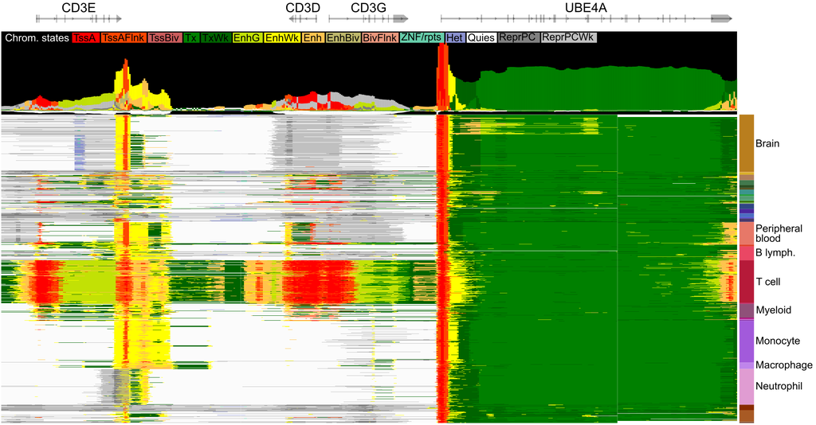

Fig. 2I: Epilogos visualization of one of the important Biospecimen classifier regions enriched in the `T cell receptor complex` GO term from Fig. 2H.

See Annex A for a more detailled Epilogos color legend.

### J - Copy Number Alteration (CNA) Signatures and SHAP values

Note: The code uses the acronym CNV (Copy Number Variant/Variation) instead of CNA.

See CNV_treatment.ipynb ([permalink](https://github.com/labjacquespe/EpiClass/blob/e87306bccecd3e35d9ffdbb5ddb29fcaa0800a35/src/python/epiclass/utils/notebooks/paper/CNV_treatment.ipynb)) for the creation of the CNA stats. The following figures represent the Z-scores of the signal within the top SHAP features (N=336) vs 200 random feature sets of same size, for signatures created using patients samples with cancer types similar to EpiAtlas content (see paper Methods).  
Load z-scores.

```python
cnv_dir = base_data_dir / "CNV"
cnv_intersection_results = (
    cnv_dir
    / "signature_analysis"
    / "epiatlas_cancer_types"
    / "important_cancer_features_z_scores_vs_random200.tsv"
)
PathChecker.check_file(cnv_intersection_results)

cnv_df = pd.read_csv(cnv_intersection_results, sep="\t", index_col=0)
cnv_df.name = cnv_intersection_results.stem
```

Define graphing function `plot_cnv_zscores`, which uses the CNA groups defined by [Signatures of copy number alterations in human cancer](https://doi.org/10.1038/s41586-022-04738-6). See Supplementary Table 8 for details.

```python
def plot_cnv_zscores(cnv_df: pd.DataFrame) -> None:
    """Plot z-scores of top SHAP features vs random feature sets, grouped by CNV groups.

    Args:
        cnv_df: The DataFrame with z-scores.
    """
    n_beds = int(cnv_df.name.split("random")[1])
    signature_subset_name = "EpiATLAS cancer types"

    CN_groups = [
        [f"CN{i}" for i in range(1, 4)],
        [f"CN{i}" for i in range(9, 13)],
        [f"CN{i}" for i in range(13, 17)],
        [f"CN{i}" for i in range(17, 18)],
        [f"CN{i}" for i in range(18, 22)],
        [f"CN{i}" for i in range(4, 9)],
    ]
    CN_names = [
        "CN1-CN3",
        "CN9-CN12",
        "CN13-CN16",
        "CN17",
        "CN18-CN21",
        "CN4-CN8",
    ]

    # Assign groups to the DataFrame
    cnv_df["group"] = "Other"
    for i, group in enumerate(CN_groups):
        cnv_df.loc[cnv_df.index.isin(group), "group"] = CN_names[i]

    # Sort groups
    group_medians = (
        cnv_df.groupby("group")["z_score"].median().sort_values(ascending=False)
    )
    sorted_CN_names = group_medians.index.tolist()

    # Create the figure
    fig = go.Figure()

    for group in sorted_CN_names:
        group_data = cnv_df[cnv_df["group"] == group]
        marker_size = 4 if group != "CN17" else 6

        # Add the box plot without points
        fig.add_trace(
            go.Box(
                y=group_data["z_score"],
                name=group,
                boxmean=True,
                boxpoints=False,  # Don't show points in the box plot
                line=dict(color="black"),
                fillcolor="rgba(255,255,255,0)",
                showlegend=False,
            )
        )

        # Add scatter plot for individual points
        fig.add_trace(
            go.Scatter(
                x=[group] * len(group_data),
                y=group_data["z_score"],
                mode="markers",
                marker=dict(
                    color="red",
                    size=marker_size,
                ),
                name=group,
                showlegend=False,
                text=group_data.index,  # Use CN names as hover text
                hoverinfo="text+y",  # Show CN name and y-value on hover
            )
        )
    # Update layout
    fig.update_layout(
        xaxis_title="CNA Group",
        yaxis_title="Z-score",
        **main_title_settings
    )

    # Add a horizontal line at y=0 for reference
    fig.add_hline(y=0, line_color="grey", line_width=1)

    fig.show()
```

Graph.

```python
plot_cnv_zscores(cnv_df)
```

[interactive chart not shown]

Define the graphing function `plot_cnv_zscores_alt`, which groups CNA by focal vs chromosomal events.

```python
def plot_cnv_zscores_alt(cnv_df: pd.DataFrame) -> None:
    """Plot z-scores of top SHAP features vs random feature sets, grouped by focal vs chromosomal events.

    Args:
        cnv_df: The DataFrame with z-scores.
    """
    n_beds = int(cnv_df.name.split("random")[1])
    signature_subset_name = "EpiATLAS cancer types"

    # Assign groups
    CN_groups = [
        [f"CN{i}" for i in range(1, 9)] + [f"CN{i}" for i in range(13, 17)],
        [f"CN{i}" for i in range(9, 13)] + [f"CN{i}" for i in range(17, 22)],
    ]
    CN_names = [
        "Chromosomal events (CN1-CN8, CN13-CN16)",
        "Focal events (CN9-CN12, CN17-CN21)",
    ]

    # Assign groups to the DataFrame
    cnv_df["group"] = "Other"
    for i, group in enumerate(CN_groups):
        cnv_df.loc[cnv_df.index.isin(group), "group"] = CN_names[i]

    # Sort groups
    group_medians = (
        cnv_df.groupby("group")["z_score"].median().sort_values(ascending=False)
    )
    sorted_CN_names = group_medians.index.tolist()

    # Create the figure
    fig = go.Figure()

    for group in sorted_CN_names:
        group_data = cnv_df[cnv_df["group"] == group]
        hover_text = [
            f"{CN_name}: Z={val:.3f}"
            for CN_name, val in zip(group_data.index, group_data["z_score"])
        ]

        # Add the box plot without points
        fig.add_trace(
            go.Box(
                y=group_data["z_score"],
                name=group,
                boxmean=True,
                boxpoints="all",
                line=dict(color="black"),
                fillcolor="rgba(255,255,255,0)",
                showlegend=False,
                hoverinfo="text",  # Show CN name and y-value on hover
                hovertext=hover_text,
            )
        )

    # Update layout
    fig.update_layout(
        xaxis_title="Copy Number Alteration Event Type",
        yaxis_title="CNA Enrichment (Z-score)",
        **main_title_settings
    )

    # Add a horizontal line at y=0 for reference
    fig.add_hline(y=0, line_color="grey", line_width=1)

    fig.show()
```

Graph.

```python
plot_cnv_zscores_alt(cnv_df)
```

[interactive chart not shown]

Fig. 2J: Distribution of the z-score enrichment for copy number (CN) signatures (dots) in genomic regions identified as important by the Cancer status classifier compared to random control regions. CN signatures are grouped as being mostly associated with focal changes (CN9-12,17-21) or chromosomal ones (CN1-8,13-16). Boxplot elements are as in Fig 2A.

## Supplementary Figures 5 to 7

See the Additional Supplementary Figures page (separate to limit maximum website page size and loading times).

## Annex A - Epilogos color legend

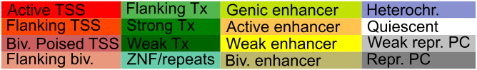

- biv = bivalent
- Tx = Transcription
- Repr = Repressed
- PC = Polycomb